# HW 2

due 2/16/23

Author

Ava Waters

Published

February 13, 2023

Please remember that this homework is to be done individually!

**Look at `hw2_instructions.html` for more information on the two data sets and for helpful hints throughout.**

```r
library(tidyverse)
library(robotstxt)
library(rvest)
library(scales)
```

```python
# import packages
import matplotlib.pyplot as plt
import seaborn as sns
```

## Q1

```r
# load file
pac_all <- read_csv("data/pac-all.csv", show_col_types=FALSE)
```

There are 2413 observations and 6 variables.

## Q2

```r
# separate country_parent col into country and parent cols
pac_all <- pac_all %>% separate(country_parent, c("country", "parent"), sep="/", extra="merge")

# print first 10 rows
pac_all
```

```
# A tibble: 2,413 × 7
   name                                  country parent total dems  repubs  year
   <chr>                                 <chr>   <chr>  <chr> <chr> <chr>  <dbl>
 1 7-Eleven                              Japan   Ito-Y… $8,5… $1,5… $7,000  2000
 2 ABB Group                             Switze… Asea … $46,… $17,… $28,5…  2000
 3 Accenture                             UK      Accen… $75,… $23,… $52,9…  2000
 4 ACE INA                               UK      ACE G… $38,… $12,… $26,0…  2000
 5 Acuson Corp (Siemens AG)              Germany Sieme… $2,0… $2,0… $0      2000
 6 Adtranz (DaimlerChrysler)             Germany Daiml… $10,… $10,… $500    2000
 7 AE Staley Manufacturing (Tate & Lyle) UK      Tate … $24,… $10,… $14,0…  2000
 8 AEGON USA (AEGON NV)                  Nether… Aegon… $58,… $10,… $47,7…  2000
 9 AIM Management Group                  UK      AMVES… $25,… $10,… $15,0…  2000
10 Air Liquide America                   France  L'Air… $0    $0    $0      2000
# … with 2,403 more rows
```

## Q3

```r
# remove $ and , from the columns and , using | as the OR operator
# and convert them to nuumeric
pac_all$total <- str_remove_all(pac_all$total, "\\$|,") %>% as.numeric()
pac_all$dems <- str_remove_all(pac_all$dems, "\\$|,") %>% as.numeric()
pac_all$repubs <- str_remove_all(pac_all$repubs, "\\$|,") %>% as.numeric()

# print first 10 rows
pac_all
```

```
# A tibble: 2,413 × 7
   name                                  country parent total  dems repubs  year
   <chr>                                 <chr>   <chr>  <dbl> <dbl>  <dbl> <dbl>
 1 7-Eleven                              Japan   Ito-Y…  8500  1500   7000  2000
 2 ABB Group                             Switze… Asea … 46000 17000  28500  2000
 3 Accenture                             UK      Accen… 75984 23000  52984  2000
 4 ACE INA                               UK      ACE G… 38500 12500  26000  2000
 5 Acuson Corp (Siemens AG)              Germany Sieme…  2000  2000      0  2000
 6 Adtranz (DaimlerChrysler)             Germany Daiml… 10500 10000    500  2000
 7 AE Staley Manufacturing (Tate & Lyle) UK      Tate … 24000 10000  14000  2000
 8 AEGON USA (AEGON NV)                  Nether… Aegon… 58250 10500  47750  2000
 9 AIM Management Group                  UK      AMVES… 25000 10000  15000  2000
10 Air Liquide America                   France  L'Air…     0     0      0  2000
# … with 2,403 more rows
```

## Q4

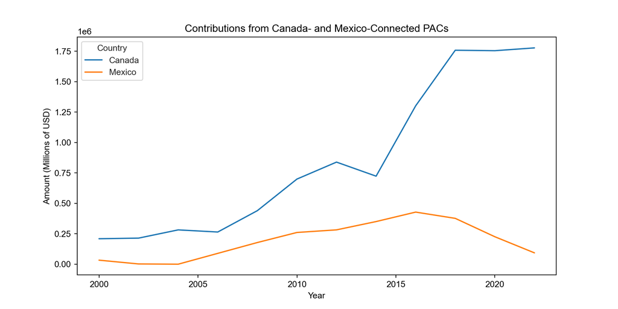

```python
# save pac_all as python df so i don't have to keep accessing it thru the R interface object
pac_all = r.pac_all

# filter to include data abt Canada and Mexico
# group by country and year
# sum the total col
# turn back into data frame
can_mex_pac = pac_all[pac_all["country"].isin(["Canada", "Mexico"])].groupby(["country", "year"])["total"].sum().reset_index(name="total")

# make lineplot
fig, ax = plt.subplots()
sns.set_style("whitegrid")

sns.lineplot(data = can_mex_pac, x = "year", y = "total", hue = "country", ax = ax)

# add figure and axes labels
ax.set(title = "Contributions from Canada- and Mexico-Connected PACs", xlabel = "Year", ylabel = "Amount (Millions of USD)")

# edit legend title
plt.legend(title="Country")

plt.show()
```

The graph reveals that Canadian PACs have spent more than Mexican PACs every midterm-election since 2000. From 2014 to 2018, Canada increased their spending by over a million. After 2016, Mexico decreased their spending, which makes sense given the President’s view towards Mexico. While there is no breakdown of the proportion of money going to each political party, it would be interesting to see what party Canada was supporting more after 2014.